# programmerings_uppgift

```python
from sqlalchemy import create_engine
import pandas as pd
import matplotlib.pyplot as plt
import matplotlib.ticker as mtick
import numpy as np
from scipy.stats import ttest_ind, t
```

```python
engine = create_engine(
    "mssql+pymssql://sa:Password!@localhost:1433/AdventureWorks2022?tds_version=7.4",
)
db = engine.connect()
pd.set_option("display.float_format", "{:.6f}".format)
```

## 1. Deskriptiv sammanfattning över databasen AdventureWorks2022

##### Databasen tillhör det fiktiva företaget AdventureWorks som är verksamt inom försäljning av cycklar, reservdelar och diverse tillbehör. Den är omfattande och strukturerad i fem olika scheman, där varje schema innehåller flera tabeller som tillsammans täcker alla aspekter av företagets verksamhet.

### HumanResources

Detta schema innehåller detaljerad information om alla anstälda. Här kan vi hitta data om deras namn, lön, anställningsdatum, position och annan relevant information inom företaget.

### Sales

Som namnet tyder på är detta schema dedikerat till data om allt relaterad till försäljning.

### Person

Alla personer associerat med företaget så som anställda, försäljare, kunder och leverantörer.

### Production

Allt som produceras och säljs. Det omfattar information om produkter, produktkategorier, komponenter osv.

### Purchasing

Detta schema hanterar relationen med företagets leverantörer.

```python
total_num_emp = """
SELECT
    COUNT(*) NumberOfEmployees
FROM
    HumanResources.Employee
"""
total_num_emp_df = pd.read_sql(total_num_emp, db)
total_num_emp_df
```

|  | NumberOfEmployees |
| --- | --- |
| 0 | 290 |

```python
emp_query = """
SELECT
    P.BusinessEntityID,
    P.FirstName,
    P.LastName,
	EMP.Gender,
    EMP.JobTitle,
    DEP.Name Department,
    EMP.HireDate,
    EMP.SalariedFlag,
	C.Country,
	C.City,
	C.Province
FROM
    Person.Person P
INNER JOIN
	(
		SELECT BAE.BusinessEntityID, PA.City, PSP.Name Province, PCR.Name Country
		FROM Person.BusinessEntityAddress BAE,
				Person.Address PA,
				Person.StateProvince PSP,
				Person.CountryRegion PCR
		WHERE
			BAE.AddressID = PA.AddressID AND
			PA.StateProvinceID = PSP.StateProvinceID AND
			PSP.CountryRegionCode = PCR.CountryRegionCode
	) C ON C.BusinessEntityID = P.BusinessEntityID
INNER JOIN
    HumanResources.Employee EMP ON P.BusinessEntityID = EMP.BusinessEntityID
INNER JOIN
	HumanResources.EmployeeDepartmentHistory EDH ON EDH.BusinessEntityID = EMP.BusinessEntityID
INNER JOIN
	HumanResources.Department DEP ON DEP.DepartmentID = EDH.DepartmentID
WHERE
    EDH.EndDate is NULL;
"""
emp_data_df = pd.read_sql(emp_query, db)

emp_data_df
```

|  | BusinessEntityID | FirstName | LastName | Gender | JobTitle | Department | HireDate | SalariedFlag | Country | City | Province |
| --- | --- | --- | --- | --- | --- | --- | --- | --- | --- | --- | --- |
| 0 | 1 | Ken | Sánchez | M | Chief Executive Officer | Executive | 2009-01-14 | True | United States | Newport Hills | Washington |
| 1 | 2 | Terri | Duffy | F | Vice President of Engineering | Engineering | 2008-01-31 | True | United States | Renton | Washington |
| 2 | 3 | Roberto | Tamburello | M | Engineering Manager | Engineering | 2007-11-11 | True | United States | Redmond | Washington |
| 3 | 4 | Rob | Walters | M | Senior Tool Designer | Tool Design | 2007-12-05 | False | United States | Minneapolis | Minnesota |
| 4 | 5 | Gail | Erickson | F | Design Engineer | Engineering | 2008-01-06 | True | United States | Bellevue | Washington |
| ... | ... | ... | ... | ... | ... | ... | ... | ... | ... | ... | ... |
| 285 | 286 | Lynn | Tsoflias | F | Sales Representative | Sales | 2013-05-30 | True | Australia | Melbourne | Victoria |
| 286 | 287 | Amy | Alberts | F | European Sales Manager | Sales | 2012-04-16 | True | United States | Renton | Washington |
| 287 | 288 | Rachel | Valdez | F | Sales Representative | Sales | 2013-05-30 | True | Germany | Berlin | Hamburg |
| 288 | 289 | Jae | Pak | F | Sales Representative | Sales | 2012-05-30 | True | United Kingdom | Cambridge | England |
| 289 | 290 | Ranjit | Varkey Chudukatil | M | Sales Representative | Sales | 2012-05-30 | True | France | Bordeaux | Gironde |

290 rows × 11 columns

#### Adventureworks har totalt 290 anställda. Över 60% jobbar inom production, med resterande roller jämt fördelade.

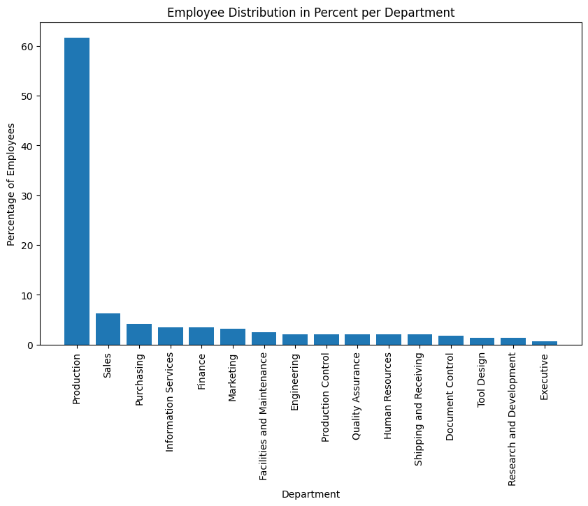

```python
emps_per_dep = emp_data_df["Department"].value_counts()
emps_per_dep_percent = (emps_per_dep / 290) * 100
plt.figure(figsize=(10, 6))
plt.bar(emps_per_dep_percent.index, emps_per_dep_percent.values)
plt.xlabel("Department")
plt.ylabel("Percentage of Employees")
plt.title("Employee Distribution in Percent per Department")
plt.xticks(rotation=90)
plt.show()
```

### Databasen innehåller information om gender dvs kön och vi kan se det fiktiva företaget är mans dominerad med över 70% av anstälda som är män.

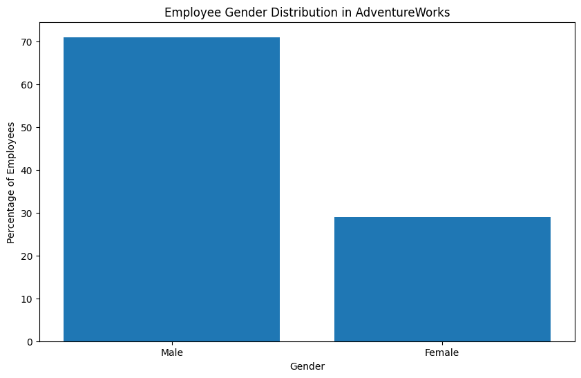

```python
emp_gender = emp_data_df["Gender"].value_counts()
emp_gender_percent = (emp_gender / 290) * 100
plt.figure(figsize=(10, 6))
plt.bar(["Male", "Female"], emp_gender_percent.values)
plt.xlabel("Gender")
plt.ylabel("Percentage of Employees")
plt.title("Employee Gender Distribution in AdventureWorks")
plt.show()
```

#### Utöver USA är företaget även representerat i följande länder:

- Australien
- Storbritannien
- Frankrike
- Tyskland
- Kanada

#### Detta bekräftar att AdventureWorks inte bara är ett Amerikanskt utan också ett internationellt företag med en relativ bred spridning. Detta öppnar upp ytterliggare möjligheter att expandera verksamheten i framtiden.

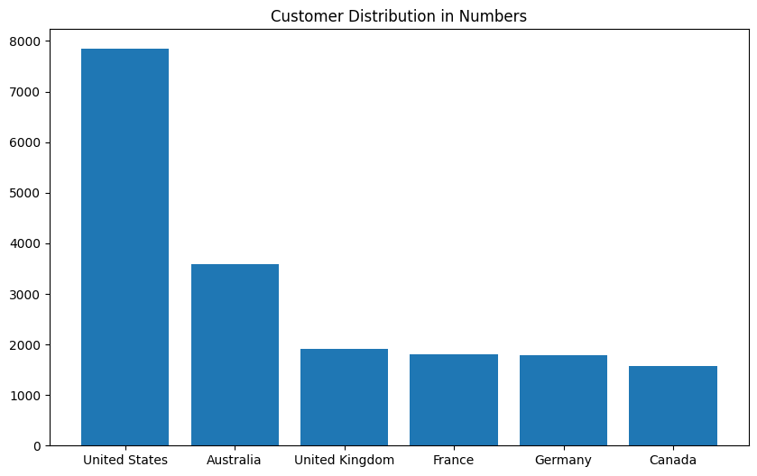

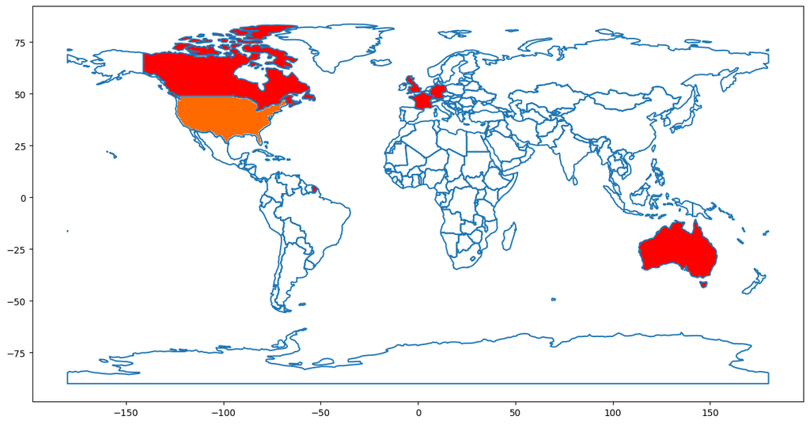

```
Country
United States     7843
Australia         3591
United Kingdom    1913
France            1810
Germany           1780
Canada            1571
Name: Country, dtype: int64
```

```python
from IPython.display import Image

cust_query = """
SELECT
    P.BusinessEntityID,
    P.FirstName,
    P.LastName,
	C.Country,
	C.City,
	C.Province
FROM
    Person.Person P
INNER JOIN
    Sales.Customer Cust ON P.BusinessEntityID = Cust.PersonID
INNER JOIN
	(
		SELECT BAE.BusinessEntityID, PA.City, PSP.Name Province, PCR.Name Country
		FROM Person.BusinessEntityAddress BAE,
				Person.Address PA,
				Person.StateProvince PSP,
				Person.CountryRegion PCR
		WHERE
			BAE.AddressID = PA.AddressID AND
			PA.StateProvinceID = PSP.StateProvinceID AND
			PSP.CountryRegionCode = PCR.CountryRegionCode
	) C ON C.BusinessEntityID = Cust.PersonID
"""
cust_data_df = pd.read_sql(cust_query, db)

cust_dist = cust_data_df.groupby("Country").Country.count().sort_values(ascending=False)
plt.figure(figsize=(10, 6))
plt.bar(cust_dist.index, cust_dist.values)
plt.title("Customer Distribution in Numbers")
plt.show()


display(Image(filename="emp_map.png"))

print(cust_dist)
```

#### AdventureWorks säljer cyklar, reservdelar och produkter relaterade med cykling. Genom ett enkelt query kan vi visualisera det bättre.

#### Företaget har ett brett sortiment där även kläder säljs.

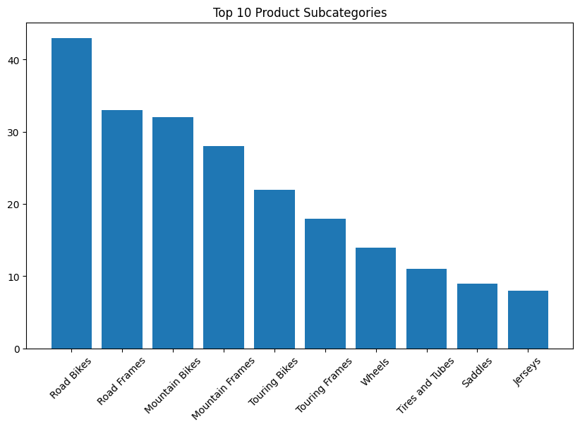

```python
product_subcategory_query = """
SELECT TOP 10
    psc.Name AS SubCategory,
    COUNT(p.ProductID) ProductCount
FROM
    Production.Product p
INNER JOIN
    Production.ProductSubcategory psc ON p.ProductSubcategoryID = psc.ProductSubcategoryID
GROUP BY
    psc.Name
ORDER BY
    ProductCount DESC;
"""


product_category_df = pd.read_sql(product_subcategory_query, db)
plt.figure(figsize=(10, 6))
plt.bar(product_category_df["SubCategory"], product_category_df["ProductCount"])
plt.title("Top 10 Product Subcategories")
plt.xticks(rotation=45)
plt.show()
```

### Försäljningen per region/land i miljoner dollar. USA med en stor marginal nummer ett. Företaget har en omsättning på flera miljoner som vi kommer se på nästa diagram.

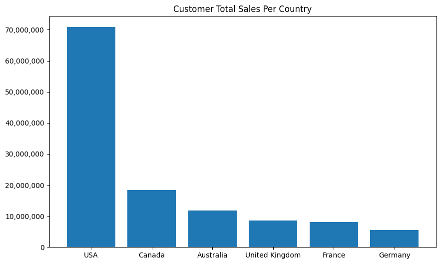

|  | TerritoryName | TotalSales |
| --- | --- | --- |
| 0 | USA | 70829863.000000 |
| 1 | Canada | 18398929.000000 |
| 2 | Australia | 11814376.000000 |
| 3 | United Kingdom | 8574049.000000 |
| 4 | France | 8119749.000000 |
| 5 | Germany | 5479820.000000 |

```python
total_sales_query = """
SELECT
    CASE
        WHEN st.Name IN ('Southwest','Northwest','Central', 'Southeast', 'Northeast') THEN 'USA'
        ELSE st.Name
    END TerritoryName,
    ROUND(SUM(soh.TotalDue), 0) TotalSales
FROM
    Sales.SalesOrderHeader soh
INNER JOIN
    Sales.SalesTerritory st ON soh.TerritoryID = st.TerritoryID
GROUP BY
    CASE
        WHEN st.Name IN ('Southwest','Northwest','Central', 'Southeast', 'Northeast') THEN 'USA'
        ELSE st.Name
    END
ORDER BY TotalSales DESC
"""

total_sales_df = pd.read_sql(total_sales_query, db)

plt.figure(figsize=(10, 6))
plt.bar(total_sales_df["TerritoryName"], total_sales_df["TotalSales"])
plt.gca().yaxis.set_major_formatter(
    mtick.FuncFormatter(lambda x, p: format(int(x), ","))
)
plt.title("Customer Total Sales Per Country")
plt.show()
total_sales_df
```

#### Mellan år 2011 och 2012 ökade försäljningen markant. Under 2013 fortsatte den positiva trenden. 2014 noteras som ett dåligt år med en tydlig nedgång i försäljning. Dock är det viktigt att notera datan för 2014 är ofullständig vilket gör det svårare att dra slutsatser.

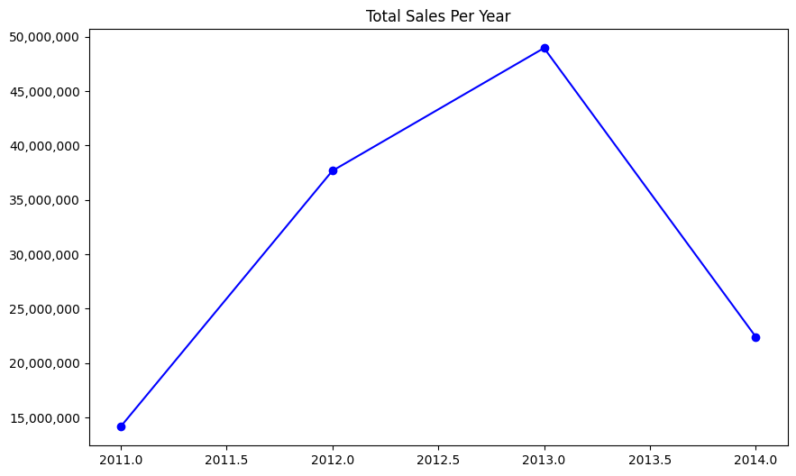

|  | SalesYear | TotalSales |
| --- | --- | --- |
| 0 | 2014 | 22419498.315700 |
| 1 | 2013 | 48965887.963200 |
| 2 | 2012 | 37675700.312000 |
| 3 | 2011 | 14155699.525000 |

```python
sales_by_year_query = """
SELECT
    YEAR(OrderDate) SalesYear,
    SUM(TotalDue) TotalSales
FROM
    Sales.SalesOrderHeader
GROUP BY
    YEAR(OrderDate)
ORDER BY
    SalesYear DESC;
"""
sales_by_year_df = pd.read_sql(sales_by_year_query, db)

plt.figure(figsize=(10, 6))
plt.title("Total Sales Per Year")
plt.plot(
    sales_by_year_df["SalesYear"],
    sales_by_year_df["TotalSales"],
    marker="o",
    linestyle="-",
    color="blue",
)
plt.gca().yaxis.set_major_formatter(
    mtick.FuncFormatter(lambda x, p: format(int(x), ","))
)
plt.show()
sales_by_year_df
```

## 2. Statistiskt Dataanalys

#### Jag har valt att undersöka prestandan hos alla säljare i AdventureWorks-databasen. Syftet med analysen är att besvara följande frågor: Finns det en statistiskt signifikant skillnad i prestanda och lön mellan könen? Vi antar att stickproven är normalfördelade och oberoende.

```python
sales_by_emp_query = """
SELECT
    e.BusinessEntityID,
    eph.Rate Salary,
    ROUND(sp.SalesYTD, 0) TotalSalesYTD
FROM
    Sales.SalesPerson sp
INNER JOIN
    HumanResources.Employee e ON sp.BusinessEntityID = e.BusinessEntityID
INNER JOIN
    HumanResources.EmployeePayHistory eph ON e.BusinessEntityID = eph.BusinessEntityID
"""
sales_by_emp_df = pd.read_sql_query(sales_by_emp_query, db)
sales_by_emp_df = pd.merge(
    emp_data_df, sales_by_emp_df, on="BusinessEntityID", how="inner"
)
# sales_by_emp_df.sort_values("TotalSalesYTD", ascending=False)
```

#### När vi kollar på medelvärdet mellan könerna ser vi en tydlig skillnad. Dock när vi kollar på medianen får vi en annan bild. Vi undersöker vidare genom att göra en konfidensintervall på skillnaden mellan medelvärdena.

```
Medelvärde försälning:
 Gender
F   2382717.000000
M   1959857.300000
Name: TotalSalesYTD, dtype: float64
Median försälning:
 Gender
F   1827067.000000
M   1945874.000000
Name: TotalSalesYTD, dtype: float64

Medelvärde lön:
 Gender
F   26.651771
M   28.081720
Name: Salary, dtype: float64
Median lön:
 Gender
F   23.076900
M   23.076900
Name: Salary, dtype: float64
```

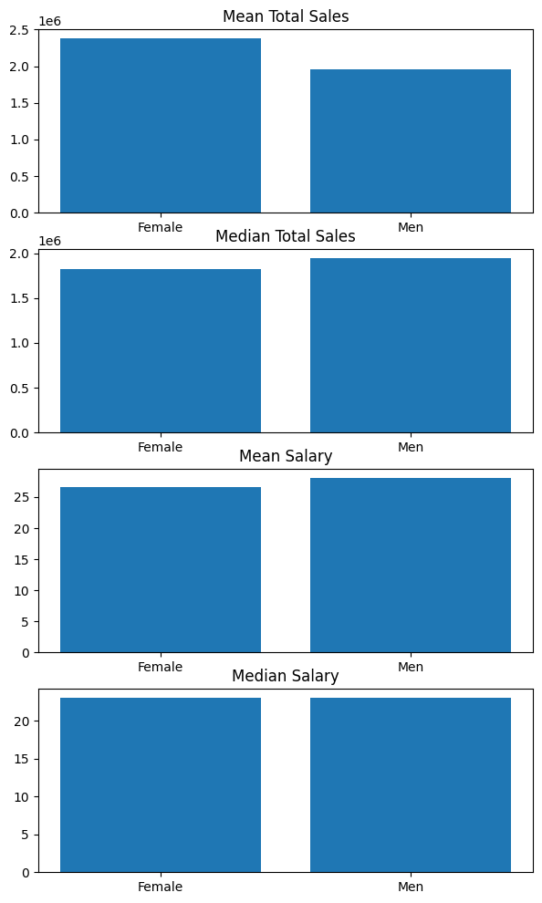

```python
mean_female_vs_men = sales_by_emp_df.groupby("Gender")["TotalSalesYTD"].mean()
median_female_vs_men = sales_by_emp_df.groupby("Gender")["TotalSalesYTD"].median()

mean_salary_female_vs_men = sales_by_emp_df.groupby("Gender")["Salary"].mean()
median_salary_female_vs_men = sales_by_emp_df.groupby("Gender")[
    "Salary"
].median()

print("Medelvärde försälning:\n", mean_female_vs_men)
print("Median försälning:\n", median_female_vs_men)
print()
print("Medelvärde lön:\n", mean_salary_female_vs_men)
print("Median lön:\n", median_salary_female_vs_men)


fig, ax = plt.subplots(4, 1, figsize=(7, 12))

ax[0].bar(["Female", "Men"], mean_female_vs_men.values)
ax[0].set_title("Mean Total Sales")

ax[1].bar(["Female", "Men"], median_female_vs_men.values)
ax[1].set_title("Median Total Sales")

ax[2].bar(["Female", "Men"], mean_salary_female_vs_men.values)
ax[2].set_title("Mean Salary")

ax[3].bar(["Female", "Men"], median_salary_female_vs_men.values)
ax[3].set_title("Median Salary")
plt.show()
```

## Med 95 % säkerhet kan jag säga att den sanna skillnaden ligger mellan (-906155.55, 1751874.95) för försäljning och (-12.07, 9.20) för lön. Detta innebär att det inte finns en statisktiskt signifikant skillnad mellan de två könen, då båda intervallen inkluderar noll.

```python
# Beräkna stickprovsstorlek, medelvärde, varians för varje stickprov.
female_mean = sales_by_emp_df[sales_by_emp_df["Gender"] == "F"]["TotalSalesYTD"].mean()
female_var = sales_by_emp_df[sales_by_emp_df["Gender"] == "F"]["TotalSalesYTD"].var()
female_n = sales_by_emp_df[sales_by_emp_df["Gender"] == "F"]["TotalSalesYTD"].count()

male_mean = sales_by_emp_df[sales_by_emp_df["Gender"] == "M"]["TotalSalesYTD"].mean()
male_var = sales_by_emp_df[sales_by_emp_df["Gender"] == "M"]["TotalSalesYTD"].var()
male_n = sales_by_emp_df[sales_by_emp_df["Gender"] == "M"]["TotalSalesYTD"].count()

# Beräkna s2p
s2p = ((female_n - 1) * female_var + (male_n - 1) * male_var) / (female_n + male_n - 2)

# Beräkna Standard Error
se = np.sqrt(s2p * (1 / female_n + 1 / male_n))

# Frihetsgrader
df = female_n + male_n - 2

# Signifikans nivå 95%
t_krit = t.ppf(1 - 0.025, df)

ci_lower_1 = (female_mean - male_mean) - t_krit * se
ci_upper_1 = (female_mean - male_mean) + t_krit * se

print(f"95% Konfidensintervall för försäljning: ({ci_lower_1}, {ci_upper_1})")
```

```
95% Konfidensintervall för försäljning: (-906155.5453598127, 1751874.9453598126)
```

```python
# Beräkna stickprovsstorlek, medelvärde, varians för varje stickprov.
female_mean = sales_by_emp_df[sales_by_emp_df["Gender"] == "F"]["Salary"].mean()
female_var = sales_by_emp_df[sales_by_emp_df["Gender"] == "F"]["Salary"].var()
female_n = sales_by_emp_df[sales_by_emp_df["Gender"] == "F"]["Salary"].count()

male_mean = sales_by_emp_df[sales_by_emp_df["Gender"] == "M"]["Salary"].mean()
male_var = sales_by_emp_df[sales_by_emp_df["Gender"] == "M"]["Salary"].var()
male_n = sales_by_emp_df[sales_by_emp_df["Gender"] == "M"]["Salary"].count()

# Beräkna s2p
s2p = ((female_n - 1) * female_var + (male_n - 1) * male_var) / (female_n + male_n - 2)

# Beräkna Standard Error
se = np.sqrt(s2p * (1 / female_n + 1 / male_n))

# Frihetsgrader
df = female_n + male_n - 2

# Signifikans nivå 95%
t_krit = t.ppf(1 - 0.025, df)

ci_lower_2 = (female_mean - male_mean) - t_krit * se
ci_upper_2 = (female_mean - male_mean) + t_krit * se

print(f"95% Konfidensintervall för lön: ({ci_lower_2}, {ci_upper_2})")
```

```
95% Konfidensintervall för lön: (-12.068403016438122, 9.208505873580972)
```

#### H0: female_mean = male_mean

#### H1: female_mean != male_mean

```python
female_sales = sales_by_emp_df[sales_by_emp_df["Gender"] == "F"]["TotalSalesYTD"]
male_sales = sales_by_emp_df[sales_by_emp_df["Gender"] == "M"]["TotalSalesYTD"]

female_salary = sales_by_emp_df[sales_by_emp_df["Gender"] == "F"]["Salary"]
male_salary = sales_by_emp_df[sales_by_emp_df["Gender"] == "M"]["Salary"]

t_stat_1, p_value_1 = ttest_ind(female_sales, male_sales)
print("P-värde för försäljning:", p_value_1)

t_stat_2, p_value_2 = ttest_ind(female_salary, female_salary)
print("P-värde för lön:", p_value_2)
```

```
P-värde för försäljning: 0.5079887725981127
P-värde för lön: 1.0
```

## 3. Executive summary

#### Översikt

- Min analys fokuserar på prestandan och lönerna hos säljare på företaget, uppdelat mellan könen. Mitt mål var att undersöka om det fanns en statistiskt signifikant skillnad i prestation och ersättning mellan kvinnor och män inom företaget. Som källa användes företagets databas och statistiska tester genomfördes för att dra slutsatser.

#### Problem

- Problemet som analyserades var att identifiera om företagets prestation och lönestruktur kan upplevas som rättvis. Denna analys är viktig för att säkerhetställa att företaget följer rättvisa riktlinjer och komma med rekommendationer för att undvika interna konflikter och negativt påverka de antställdas motivation.
- Mina tester visar att det inte finns en statistiskt signifikant skillnad mellan kvinnor och män i varken prestation eller ersättning. Detta indikerar att AdventureWorks efterlever rättvisa riktlinjer när det gäller vår försäljningspersonal.

#### Rekommendationer

- Trots att inga skillnader hittades, är det viktigt att företaget fortsätter på samma spår.

#### Nästa steg

- Utföra regelbundna analyser för att säkerhetställa ingen regression införs över tid.
- Analysera andra avdelningar om företagets riktlinjer efterlevs.
- Anordna utbildningar inom jämställdhet och rättvisa för ledning och HR-personalen.

### *Muntlig presentation 2025-01-03*

## 4. Självvärdering

1. Utmaningar du haft under arbetet samt hur du hanterat dem.

   Självklart var det svåraste att komma igång med arbetet. AdventureWorks2022 är en enorm relationsdatabas med ett stort antal tabeller och relationer, vilket gjorde det en utmaning att lära sig navigera databasen. Då jag hade en grund i SQL, var jag mer intresserad av hur jag kunde använda pandas dataframes för att vidarearbeta och raffinera mina resultat efter att datan har hämtats från databasen. Formelsamlingen från föregående kurs var till hjälp när jag skulle göra en konfidensintervall. En utmaning som inte direkt var kopplad till uppgiften, men ändå värd att nämna, var att få allt att fungera smidigt i en Linux-miljö.
2. Vilket betyg du anser att du skall ha och varför.

   Om kriterierna är på programmering så tycker jag VG. Jag har visat en god förmåga att arbeta med en komplex databas som AdventureWorks2022, där jag kombinerat olika verktyg och löst uppgiften effektivt. Däremot om kriterierna är baserad på min analys är jag splittrad mellan G och VG då jag upplevde den saknade lite "djup".
3. Tips du hade gett till dig själv i början av kursen nu när du slutfört den.

   Utforska, utforska utforska. Om jag hade en bättre överblick på datan, hade jag sannolikt gjort andra val.